# Mental Health Risk

Predictive Analytics for Preventive Strategies

Maurice Juma

2026-05-06

Executive Summary

```r
knitr::opts_chunk$set(echo = FALSE,warning = TRUE,message = TRUE,fig.align = "center",out.width = "100%")
```

Mental health is shaped by a complex interplay of demographic, lifestyle, psychological, and medical factors. Early identification of risk levels is critical for preventive interventions and improved well-being outcomes. This study employs a synthetic dataset of 25,000 records to simulate realistic behavioral and socioeconomic patterns, enabling machine learning–based prediction of mental health risk levels (Low, Moderate, High).

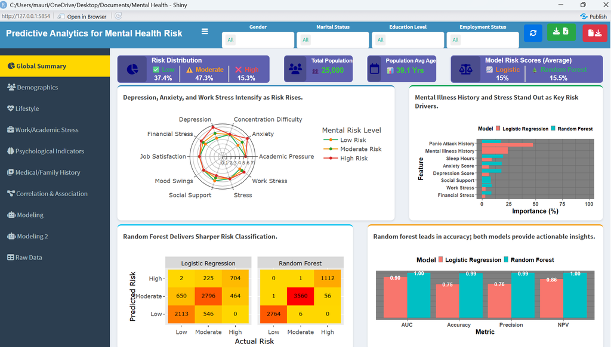

Global Metrics & Model Performance

[output not shown]

The analysis shows that **Random Forest consistently outperformed Logistic Regression**, achieving near-perfect accuracy. Key drivers of risk include **depression, anxiety, work stress, and mental illness history**. These findings emphasize the importance of integrating lifestyle and psychological monitoring into preventive health strategies.

Risk Drivers vs Protective Factors

[output not shown]

Methodology

## Dataset Overview

The dataset is structured into five major categories, each capturing a different dimension of mental health risk:

- **Demographics:** Age (18–60), gender, marital status, education, employment. These variables highlight how social and economic positioning influences vulnerability.
- **Lifestyle Factors:** Sleep hours, physical activity, screen time, social support. These indicators reflect daily habits and behaviors that directly shape well-being.
- **Work & Academic Stress:** Work stress, academic pressure, job satisfaction, financial stress, working hours. These variables capture external pressures that often escalate risk.
- **Psychological Indicators:** Anxiety, depression, stress, mood swings, concentration difficulty, panic attack history. These are direct measures of mental health symptoms and experiences.
- **Medical & Family History:** Family history of mental illness, prior diagnosis, therapy history, substance use. These variables provide context on inherited or historical vulnerabilities.

### Dataset Preview

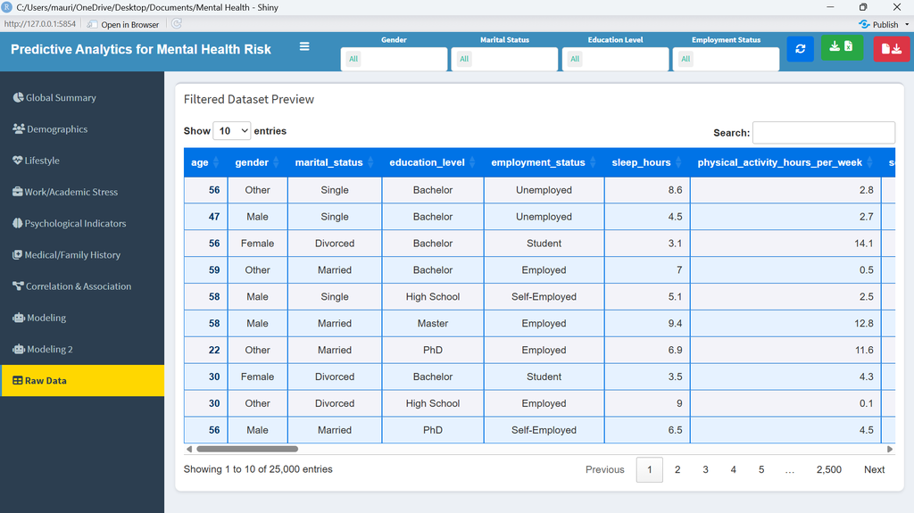

## Target Variable:

#### Mental Health Risk

- **0 =** Low Risk
- **1 =** Moderate Risk
- **2 =** High Risk

This structure ensures that the dataset captures both **external stressors** and **internal psychological states**, allowing for a holistic risk prediction model.

## Model Performance Metrics

Two predictive models were applied to classify risk levels. Their performance metrics are summarized below:

| Metric | Logistic Regression | Random Forest |
| --- | --- | --- |
| **AUC** | 0.90 | 1.00 |
| **Accuracy** | 75% | 99% |
| **Precision** | 76% | 99% |
| **NPV** | 86% | 100% |
| **Interpretability** | High – variable influence | Moderate – less interpretable |
| **Performance** | Limited accuracy, useful for explanatory analysis | Near-perfect classification, superior deployment model |

Random Forest consistently outperformed Logistic Regression, delivering sharper classification and near-perfect accuracy. Logistic Regression remains useful for interpretability and explanatory analysis, but Random Forest is the most effective model for mental health risk prediction.

Key Findings

## Demographics

**Implications:**

- HR and education systems should target stress management for midlife professionals.
- Employment programs may reduce vulnerability among unemployed populations.
- Social support initiatives should be tailored to single individuals to mitigate isolation.

### Demographic Dashboard Report

[figure not shown]

## Lifestyle Indicators

Strong social support consistently shields individuals against rising risk, underscoring the protective power of community and relationships. These findings highlight that lifestyle interventions are not just complementary but central to mental health risk reduction.

**Implications:**

### Lifestyle Dashboard Report

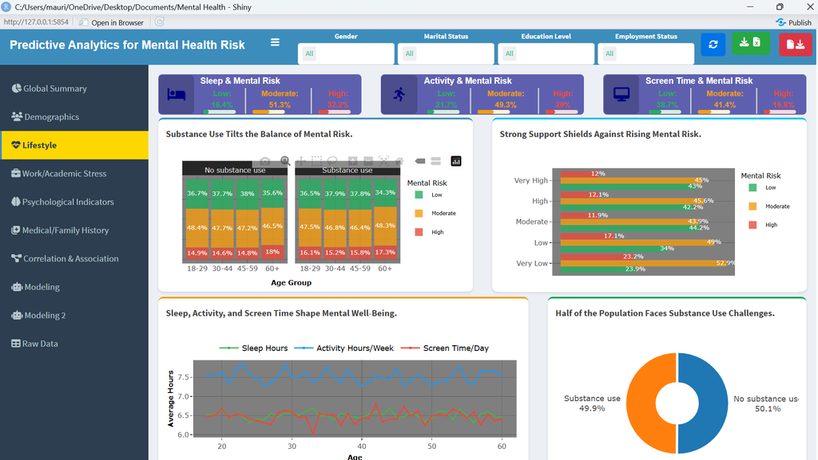

## Work & Academic Stress

These findings highlight the importance of organizational and institutional responsibility in shaping mental health outcomes. Workplaces and schools are not neutral environments; they can either exacerbate or mitigate risk depending on how they manage stress and support individuals.

**Implications:**

- Employers should design stress management programs and workload adjustments.
- Universities should integrate mental health support into academic planning.
- Policies promoting work-life balance can reduce risk across populations.

### Work & Academic Stress Dashboard Report

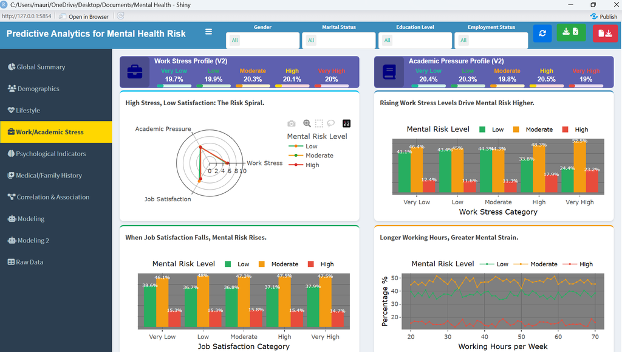

## Psychological Indicators

Psychological symptoms are among the strongest predictors of risk. Severe anxiety and depression sharply increase vulnerability, while stress alone has limited impact but amplifies outcomes when combined with anxiety or depression. Mood swings and concentration difficulty are consistent markers of elevated risk.

This suggests that mental health risk is often driven by clusters of symptoms rather than isolated factors. Individuals experiencing multiple overlapping psychological challenges are at significantly higher risk, and interventions must be designed to address these clusters holistically.

**Implications:**

- Clinicians should prioritize monitoring individuals with overlapping psychological symptoms.
- Early screening for depression and anxiety can prevent escalation.
- Integrated treatment approaches should address multiple symptoms simultaneously.

### Psychological Dashboard Report

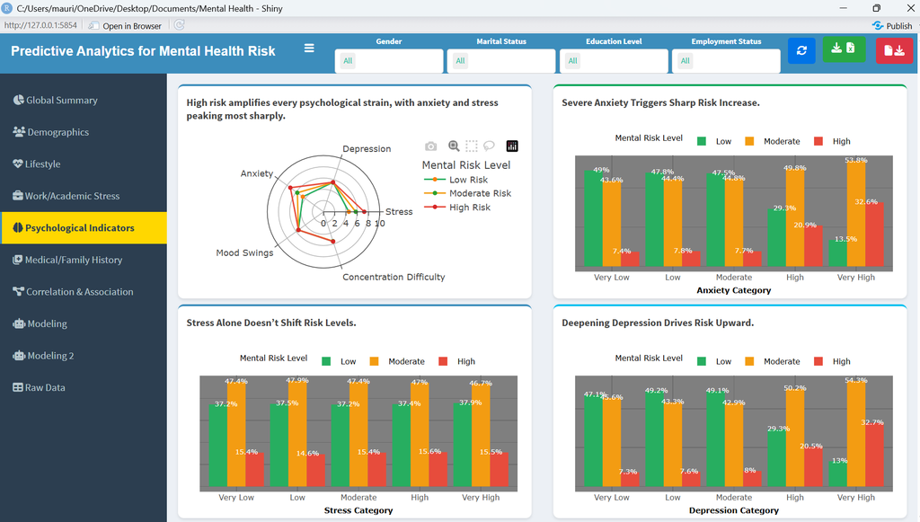

## Medical & Family History

Medical and family history significantly shape risk outcomes. Mental illness history doubles the risk burden, while panic attack history tips individuals toward high risk. Therapy alone does not significantly alter risk patterns, suggesting that treatment must be complemented by lifestyle and social interventions.

These findings highlight the importance of considering family and medical background in predictive models. Risk is not only shaped by current behaviors but also by historical and genetic factors.

**Implications:**

- Health systems should flag individuals with prior diagnoses or family history for targeted support.
- Preventive care should integrate family history into risk assessments.
- Therapy programs should be combined with community and lifestyle interventions.

### Medical History Dashboard Report

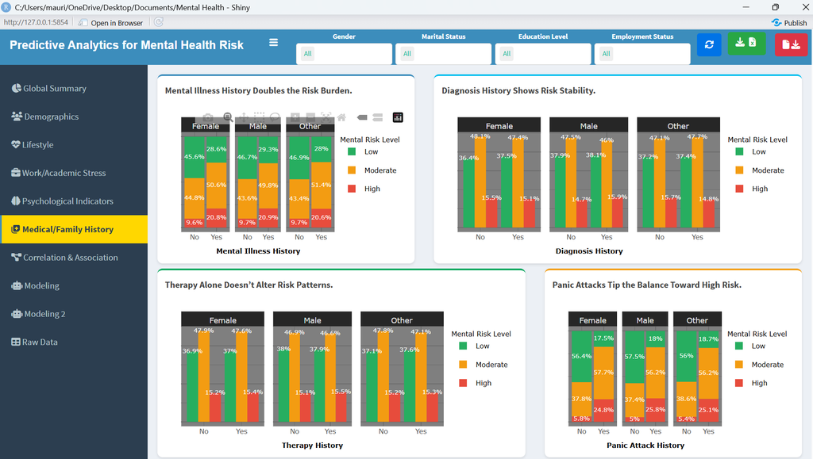

## Correlation Analysis

Correlation analysis highlights the strongest drivers of risk. Work stress and financial stress show strong positive correlations, while social support demonstrates a protective effect. Panic attacks and mental illness history are the most influential medical predictors.

This reinforces the idea that mental health risk is multidimensional, shaped by both external pressures and internal vulnerabilities. Financial stress, in particular, emerges as a critical driver, suggesting that economic stability is closely tied to psychological well-being.

**Implications:**

- Policy interventions should focus on financial stress reduction.
- Community engagement programs can strengthen protective social networks.
- Employers should monitor work stress levels as part of wellness initiatives.

### Correlation & Association Dashboard Report

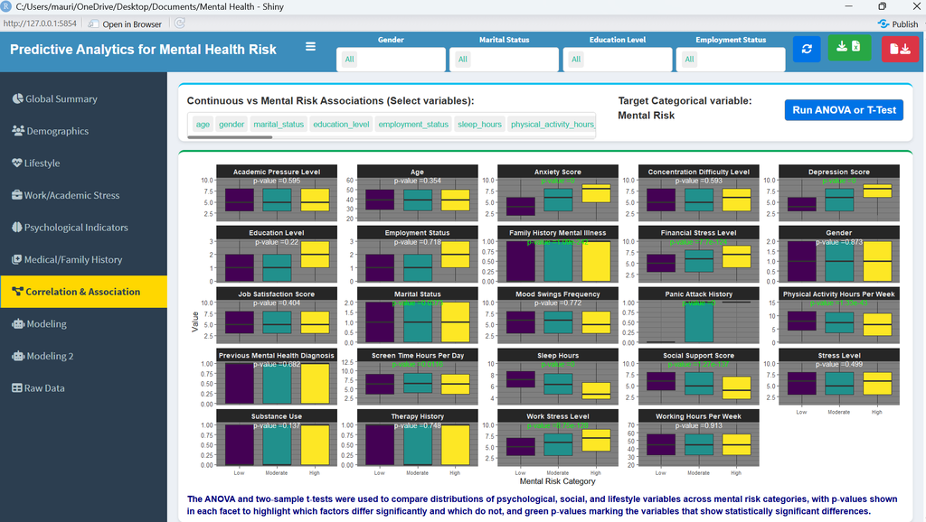

## Model Insights

Modeling results confirm Random Forest’s superiority. Logistic Regression predictions were driven by panic attack history, mental illness history, and sleep hours, but accuracy was limited. Random Forest predictions were driven by sleep, anxiety, and depression scores, achieving near-perfect classification with minimal misclassifications.

This demonstrates the value of advanced machine learning models in capturing complex, nonlinear relationships between predictors and outcomes. While Logistic Regression offers interpretability, Random Forest provides actionable accuracy that can be directly applied in real-world interventions.

**Implications:**

- Advanced machine learning models provide sharper insights and should be prioritized for deployment.
- Logistic Regression remains useful for interpretability but less accurate.
- Hybrid approaches may combine interpretability with predictive power.

### Modeling Dashboard Reports

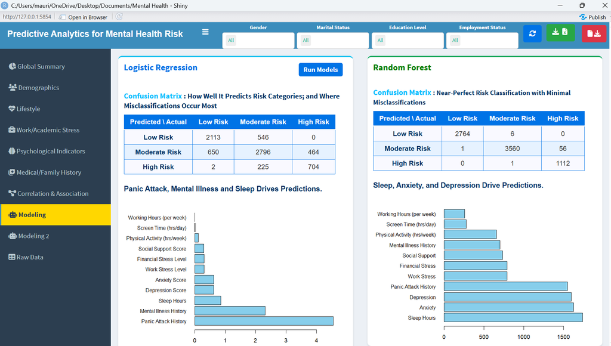

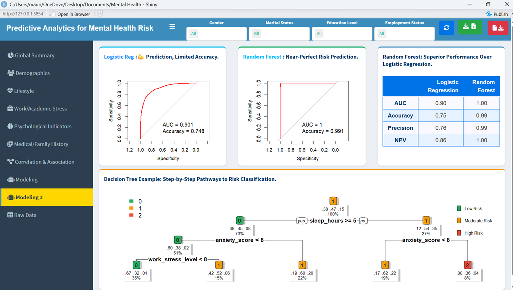

Conclusion

This study demonstrates that **Random Forest is the superior model for mental health risk prediction**, achieving near-perfect accuracy (AUC = 1.00, Accuracy = 99%) compared to Logistic Regression (AUC = 0.90, Accuracy = 75%). The findings highlight that mental health risk is shaped by a **multidimensional interplay of demographics, lifestyle, psychological symptoms, and medical history**. Key risk drivers include depression, anxiety, work stress, and prior mental illness history, while protective factors such as strong social support, physical activity, and sleep hygiene significantly reduce vulnerability.

Importantly, the analysis underscores that risk is not determined by isolated variables but by **clusters of overlapping stressors and symptoms**. For example, severe anxiety combined with depression amplifies risk far more than stress alone. This validates the need for holistic, integrated approaches in both predictive modeling and intervention design.

Recommendations

**2. Workplace & Academic Interventions**

- Employers should implement stress management programs, workload adjustments, and job satisfaction initiatives.
- Universities should integrate mental health support into academic planning, targeting students facing academic pressure.

**3. Targeted Clinical Monitoring**

- Clinicians should prioritize individuals with prior diagnoses, panic attack history, or overlapping psychological symptoms.
- Early screening for depression and anxiety clusters can prevent escalation into high-risk categories.

**4. Community & Policy Action**

- Strengthen social support networks through community engagement programs to buffer against isolation.
- Policymakers should address financial stress reduction, recognizing its strong correlation with mental health vulnerability.

**5. Model Deployment & Research**

- Deploy Random Forest models in real-world health systems for sharper, actionable predictions.
- Use Logistic Regression for interpretability, complementing Random Forest to explain variable influence.
- Explore hybrid approaches that combine interpretability with predictive accuracy for balanced decision-making.

These strategies emphasize that mental health risk reduction is not solely a clinical issue but requires coordinated action across workplaces, schools, communities, and health systems.